# Practical Machine Learning - Course Project

Armando Monsalve

2023-01-02

## Executive Summary

In this report, we are describing how a machine learning algorithm was built to predict the manner in which 6 participants did an exercise. Using cross validation, specifying what the expected out of sample error was, and why some choices were made. This prediction model was also used to predict 20 different test cases.

## Background

Using devices such as Jawbone Up, Nike FuelBand, and Fitbit it is now possible to collect a large amount of data about personal activity relatively inexpensively. These type of devices are part of the quantified self movement – a group of enthusiasts who take measurements about themselves regularly to improve their health, to find patterns in their behavior, or because they are tech geeks. One thing that people regularly do is quantify how much of a particular activity they do, but they rarely quantify how well they do it. In this project, my goal will be to use data from accelerometers on the belt, forearm, arm, and dumbbell of 6 participants.

## Loading Data

### Libraries

```r
library(dplyr)
library(caret)
library(rattle)
```

### Data: Trainning set

```r
training_set <-
  read.csv(
    file = "C:/Users/ajmon/OneDrive/AJMR/Armando Monsalve/DATA SCIENCE/COURSES/Johns Hopkins University Data Science Course/8 Practical Machine Learning/Week 4/Course Project/pml-training.csv"
    )
```

```r
training_set %>%
  dim()
```

```
## [1] 19622   160
```

### Test set

```r
testing_set <-
  read.csv(
    file = "C:/Users/ajmon/OneDrive/AJMR/Armando Monsalve/DATA SCIENCE/COURSES/Johns Hopkins University Data Science Course/8 Practical Machine Learning/Week 4/Course Project/pml-testing.csv"
    )
```

```r
testing_set %>%
  dim()
```

```
## [1]  20 160
```

### Cleaning Training Set

```r
# Identifying columns that have more than 90% of their data points null
empty_cols <-
  which(
    colSums(is.na(training_set) | training_set == "") > 0.9 * dim(training_set)[1]
  )

# Removing mostly-null and unnecessary columns
training_clean <-
  training_set[, -empty_cols]

training_clean <-
  training_clean[, -c(1:7)]
```

Let’s check how many variables we have left in my training set:

```r
training_clean %>%
  dim()
```

```
## [1] 19622    53
```

Now, let’s take a quick peek at the variables:

```r
training_clean %>%
  str()
```

```
## 'data.frame':    19622 obs. of  53 variables:
##  $ roll_belt           : num  1.41 1.41 1.42 1.48 1.48 1.45 1.42 1.42 1.43 1.45 ...
##  $ pitch_belt          : num  8.07 8.07 8.07 8.05 8.07 8.06 8.09 8.13 8.16 8.17 ...
##  $ yaw_belt            : num  -94.4 -94.4 -94.4 -94.4 -94.4 -94.4 -94.4 -94.4 -94.4 -94.4 ...
##  $ total_accel_belt    : int  3 3 3 3 3 3 3 3 3 3 ...
##  $ gyros_belt_x        : num  0 0.02 0 0.02 0.02 0.02 0.02 0.02 0.02 0.03 ...
##  $ gyros_belt_y        : num  0 0 0 0 0.02 0 0 0 0 0 ...
##  $ gyros_belt_z        : num  -0.02 -0.02 -0.02 -0.03 -0.02 -0.02 -0.02 -0.02 -0.02 0 ...
##  $ accel_belt_x        : int  -21 -22 -20 -22 -21 -21 -22 -22 -20 -21 ...
##  $ accel_belt_y        : int  4 4 5 3 2 4 3 4 2 4 ...
##  $ accel_belt_z        : int  22 22 23 21 24 21 21 21 24 22 ...
##  $ magnet_belt_x       : int  -3 -7 -2 -6 -6 0 -4 -2 1 -3 ...
##  $ magnet_belt_y       : int  599 608 600 604 600 603 599 603 602 609 ...
##  $ magnet_belt_z       : int  -313 -311 -305 -310 -302 -312 -311 -313 -312 -308 ...
##  $ roll_arm            : num  -128 -128 -128 -128 -128 -128 -128 -128 -128 -128 ...
```

[output cut: 39 more lines]

Lastly, we can check if we have variables in which we don’t have much variation. This since if we have a column wherein most of its data points are the same value, it won’t serve us well for our prediction.

```r
nearZeroVar(
  training_clean
)
```

```
## integer(0)
```

As shown, we don’t have any variables that have near-zero variance; so we keep them all for our prediction.

## Validation Partition

Since we need to test our models for out-of-sample error, I’ll go ahead and split the set in my final training and validation sets:

```r
inTrain <-
  createDataPartition(
    training_clean$classe
    , p = 0.7
    , list = FALSE
  )

training <-
  training_clean[inTrain,]

validation <-
  training_clean[-inTrain,]

# Checking how many rows my 2 sets have:
training %>%
  dim()
```

```
## [1] 13737    53
```

```r
validation %>%
  dim()
```

```
## [1] 5885   53
```

## Building and Testing Predictive Models

I’ll build multiple models in order to find the best (accuracy-wise). The models I’ll use are: Decision Trees, Random Forest and Gradient Boosted Trees.

### Cross-validation

For each model I’ll use cross-validation, so they don’t get overfitted results. I’ll implement 3-fold cross-validation:

```r
control <-
  trainControl(
    method = "cv"
    , number = 3
    , verboseIter = F
  )
```

### Decision Tree Model

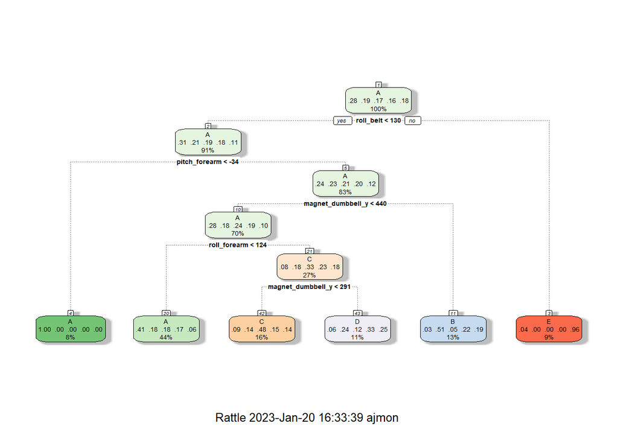

```r
set.seed(12345)
model_tree <-
  train(
    classe ~ .
    , method = "rpart"
    , data = training
    , trControl = control
    , tuneLength = 4
  )

# Resulting tree:
fancyRpartPlot(
  model_tree$finalModel
)
```

Results (Confusion Matrix and Accuracy):

```r
pred_tree <-
  predict(
    model_tree
    , validation
  )

confusionMatrix(
  pred_tree
  , as.factor(validation$classe)
)
```

```
## Confusion Matrix and Statistics
##
##           Reference
## Prediction    A    B    C    D    E
##          A 1502  484  495  418  149
##          B   25  391   27  179  130
##          C   83  107  437  119  116
##          D   39  157   67  248  165
##          E   25    0    0    0  522
##
## Overall Statistics
##
##                Accuracy : 0.5268
##                  95% CI : (0.5139, 0.5396)
##     No Information Rate : 0.2845
##     P-Value [Acc > NIR] : < 2.2e-16
##
##                   Kappa : 0.3826
##
##  Mcnemar's Test P-Value : < 2.2e-16
##
## Statistics by Class:
##
##                      Class: A Class: B Class: C Class: D Class: E
## Sensitivity            0.8973  0.34328  0.42593  0.25726  0.48244
## Specificity            0.6329  0.92394  0.91253  0.91303  0.99479
## Pos Pred Value         0.4928  0.51995  0.50696  0.36686  0.95430
## Neg Pred Value         0.9394  0.85428  0.88274  0.86255  0.89509
## Prevalence             0.2845  0.19354  0.17434  0.16381  0.18386
## Detection Rate         0.2552  0.06644  0.07426  0.04214  0.08870
## Detection Prevalence   0.5179  0.12778  0.14647  0.11487  0.09295
## Balanced Accuracy      0.7651  0.63361  0.66923  0.58514  0.73862
```

### Random Forest

Model and results (confusion matrix and accuracy):

```r
set.seed(12345)
model_rf <-
  train(
    classe ~ .
    , method = "rf"
    , data = training
    , trControl = control
    , tuneLength = 5
  )

pred_rf <-
  predict(
    model_rf
    , validation
  )

# Confusion Matrix and Accuracy
confusionMatrix(
  pred_rf
  , as.factor(validation$classe)
)
```

```
## Confusion Matrix and Statistics
##
##           Reference
## Prediction    A    B    C    D    E
##          A 1673    6    0    0    0
##          B    0 1133    4    0    0
##          C    0    0 1017   11    0
##          D    0    0    5  951    4
##          E    1    0    0    2 1078
##
## Overall Statistics
##
##                Accuracy : 0.9944
##                  95% CI : (0.9921, 0.9961)
##     No Information Rate : 0.2845
##     P-Value [Acc > NIR] : < 2.2e-16
##
##                   Kappa : 0.9929
##
##  Mcnemar's Test P-Value : NA
##
## Statistics by Class:
##
##                      Class: A Class: B Class: C Class: D Class: E
## Sensitivity            0.9994   0.9947   0.9912   0.9865   0.9963
## Specificity            0.9986   0.9992   0.9977   0.9982   0.9994
## Pos Pred Value         0.9964   0.9965   0.9893   0.9906   0.9972
## Neg Pred Value         0.9998   0.9987   0.9981   0.9974   0.9992
## Prevalence             0.2845   0.1935   0.1743   0.1638   0.1839
## Detection Rate         0.2843   0.1925   0.1728   0.1616   0.1832
## Detection Prevalence   0.2853   0.1932   0.1747   0.1631   0.1837
## Balanced Accuracy      0.9990   0.9969   0.9945   0.9923   0.9978
```

Let’s take a look at the most important variables in the model:

```r
varImp(
 model_rf
)
```

```
## rf variable importance
##
##   only 20 most important variables shown (out of 52)
##
##                      Overall
## roll_belt             100.00
## yaw_belt               66.63
## pitch_forearm          62.08
## magnet_dumbbell_z      52.35
## pitch_belt             51.73
## roll_forearm           47.41
## magnet_dumbbell_y      46.84
## magnet_dumbbell_x      28.73
## accel_dumbbell_y       26.04
## roll_dumbbell          23.80
## accel_belt_z           22.76
## magnet_belt_z          21.22
## magnet_belt_y          20.70
## accel_forearm_x        18.55
## accel_dumbbell_z       17.49
## magnet_forearm_z       17.25
## total_accel_dumbbell   15.59
## roll_arm               15.57
## gyros_belt_z           14.58
## magnet_belt_x          12.93
```

### Gradient Boosted Model

Model:

```r
set.seed(12345)
model_gbm <-
  train(
    classe ~ .
    , method = "gbm"
    , data = training
    , trControl = control
  )
```

Confusion matrix and accuracy

```r
pred_gbm <-
  predict(
    model_gbm
    , validation
  )

confusionMatrix(
  pred_gbm
  , as.factor(validation$classe)
)
```

```
## Confusion Matrix and Statistics
##
##           Reference
## Prediction    A    B    C    D    E
##          A 1651   43    0    0    1
##          B   17 1060   32    2   14
##          C    4   33  970   28    6
##          D    1    0   21  929   17
##          E    1    3    3    5 1044
##
## Overall Statistics
##
##                Accuracy : 0.9607
##                  95% CI : (0.9555, 0.9656)
##     No Information Rate : 0.2845
##     P-Value [Acc > NIR] : < 2.2e-16
##
##                   Kappa : 0.9503
##
##  Mcnemar's Test P-Value : 0.0001887
##
## Statistics by Class:
##
##                      Class: A Class: B Class: C Class: D Class: E
## Sensitivity            0.9863   0.9306   0.9454   0.9637   0.9649
## Specificity            0.9896   0.9863   0.9854   0.9921   0.9975
## Pos Pred Value         0.9740   0.9422   0.9318   0.9597   0.9886
## Neg Pred Value         0.9945   0.9834   0.9884   0.9929   0.9921
## Prevalence             0.2845   0.1935   0.1743   0.1638   0.1839
## Detection Rate         0.2805   0.1801   0.1648   0.1579   0.1774
## Detection Prevalence   0.2880   0.1912   0.1769   0.1645   0.1794
## Balanced Accuracy      0.9879   0.9585   0.9654   0.9779   0.9812
```

Let’s check how well cross-validation performed and how it affected model’s accuracy:

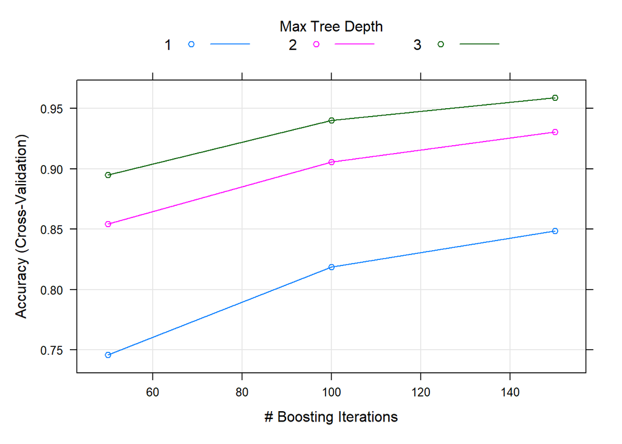

```r
plot(
  model_gbm
)
```

### Model selection

Based on accuracy, the best model for our prediction is the Random Forest model with 99% accuracy.

## Predicting classe on test set with selected model

Cleaning test data:

```r
testing_clean <-
  testing_set[, -empty_cols]

testing_clean <-
  testing_clean[, -c(1:7)]

testing_clean %>%
  dim()
```

```
## [1] 20 53
```

Predicting on test set:

```r
pred_rf_test <-
  predict(
    model_rf
    , testing_clean
  )

pred_rf_test
```

```
##  [1] B A B A A E D B A A B C B A E E A B B B
## Levels: A B C D E
```